# Tábua de mortalidade brasileira e projeção Lee-Carter

Brasil, 2000–2023, com projeção até 2050

Autor

GiulianoXRG

Data de Publicação

17/11/2026

# 1 Introdução

Uma **tábua de mortalidade** resume, para cada idade, a probabilidade de morrer e a expectativa de vida de uma população. É a base do cálculo atuarial de seguros de vida, previdência e anuidades. Como a mortalidade cai ao longo do tempo, tábuas estáticas subestimam a longevidade, por isso é preciso **projetar** a mortalidade.

Este trabalho:

1. constrói tábuas de mortalidade completas (idade simples, 0 a 100+) para o Brasil, por sexo, de 2000 a 2023, apenas com dados abertos;
2. ajusta o modelo de **Lee-Carter** e projeta a mortalidade até 2050, com intervalos de confiança para a expectativa de vida ao nascer (e0) e aos 65 anos (e65);
3. avalia o efeito da pandemia de COVID-19 (2020–2021) na projeção, comparando os ajustes de 2000–2019 e 2000–2023.

Todo o processo é reprodutível com `renv::restore()` e `targets::tar_make()`.

# 2 Dados

| Informação | Fonte | Detalhe |
| --- | --- | --- |
| Óbitos | SIM/DATASUS, declarações de óbito (SIM-DO) | `microdatasus::fetch_datasus()` e `process_sim()`, todas as UFs, 2000–2023, por ano de ocorrência e UF de residência |
| População | IBGE, Projeções da População, Revisão 2024, Tabela 1 | População em 1º de julho, por sexo e idade simples (0 a 89 e 90+) |
| Indicadores oficiais | IBGE, Projeções da População, Revisão 2024, Tabela 4 | e0, e60 e óbitos implícitos, por sexo |
| Idades 90+ | IBGE, Censo Demográfico 2022, SIDRA tabela 9514 | População por sexo e idade simples até 100+ (checagem) |

**Por que não o `brpop`?** O pacote `brpop` só oferece a população em grupos quinquenais até 80+, o que não basta para uma tábua em idade simples. Ele foi usado como checagem: a diferença no total da população em relação ao IBGE é de no máximo 1,53% entre 2000 e 2021.

## 2.1 Qualidade da informação no SIM

Os óbitos com idade ou sexo ignorados são poucos e foram redistribuídos proporcionalmente: primeiro a idade ignorada, segundo a distribuição etária do mesmo sexo e ano; depois o sexo ignorado, segundo a razão de sexo da mesma idade e ano. O total de óbitos é preservado.

Tabela 1: Óbitos registrados no SIM e percentual com idade ou sexo ignorados

| Ano | Óbitos | % idade ignorada | % sexo ignorado |
| --- | --- | --- | --- |
| 2000 | 946.686 | 0,46 | 0,10 |
| 2005 | 1.006.827 | 0,35 | 0,04 |
| 2010 | 1.136.947 | 0,35 | 0,04 |
| 2015 | 1.264.175 | 0,26 | 0,05 |
| 2019 | 1.349.801 | 0,17 | 0,04 |
| 2020 | 1.556.824 | 0,15 | 0,04 |
| 2021 | 1.832.649 | 0,13 | 0,04 |
| 2023 | 1.465.610 | 0,13 | 0,04 |

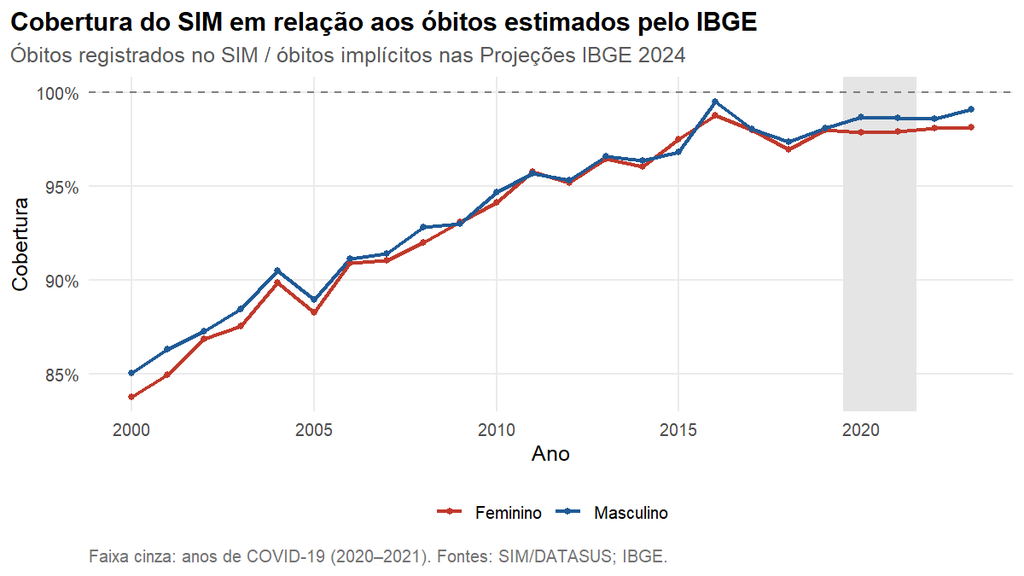

Figura 1: Óbitos do SIM em relação aos óbitos estimados pelo IBGE

A razão entre os óbitos registrados no SIM e os óbitos implícitos nas projeções do IBGE é uma medida aproximada da **cobertura** do registro. Ela mostra o principal limite dos dados brutos: no início da série, parte dos óbitos não chega ao SIM, sobretudo no Norte e no Nordeste. Isso subestima a mortalidade e superestima a expectativa de vida (ver Seção 4.2).

# 3 Metodologia

## 3.1 Taxas centrais de mortalidade

Para cada ano $t$, sexo e idade $x$:

$$m_{x,t} = \frac{D_{x,t}}{E_{x,t}},$$

com $D_{x,t}$ os óbitos do SIM (já redistribuídos) e $E_{x,t}$ a população em 1º de julho (aproximação da exposição ao risco).

## 3.2 Idades avançadas: modelo de Kannisto

Acima de 80 anos, as taxas observadas são instáveis por causa de poucos expostos, de erros de declaração de idade e do grupo aberto 90+ da população. Por isso, a partir dos 80 anos usamos o **modelo logístico de Kannisto**:

$$\mu(x) = \frac{a\,e^{b(x-80)}}{1 + a\,e^{b(x-80)}},$$

ajustado por máxima verossimilhança de Poisson nas idades 80–89, as últimas com população em idade simples.

**Kannisto ou Gompertz?** Na própria faixa de ajuste (80–89), o Gompertz teve AIC menor em 33 dos 48 ajustes (ano × sexo): até os 89 anos a desaceleração da mortalidade ainda é pequena. Mas a função do modelo aqui é **extrapolar** além dos 90. Para testar isso fora da amostra, comparamos as taxas previstas com as observadas em 2022, ano em que o Censo dá a população em idade simples até 100+ (Tabela 2). O Gompertz acerta melhor entre 91 e 95 anos, mas **superestima a mortalidade a partir de 96 anos**, porque cresce exponencialmente sem limite. O Kannisto, que tem assíntota em 1, acompanha as taxas observadas nas idades mais altas. Como o grupo 100+ e a expectativa de vida nas idades avançadas dependem justamente dessa cauda, adotamos o **Kannisto**, também usado pelo *Human Mortality Database* nas idades 80+.

Tabela 2: Taxas de mortalidade em 90–99 anos (2022): observadas (SIM / Censo 2022) e previstas pelos modelos ajustados em 80–89

| Sexo | Idade | Observada | Kannisto | Gompertz | Erro Kannisto | Erro Gompertz |
| --- | --- | --- | --- | --- | --- | --- |
| Masculino | 90 | 0,196 | 0,186 | 0,190 | -5% | -3% |
| Masculino | 92 | 0,237 | 0,222 | 0,231 | -6% | -2% |
| Masculino | 94 | 0,295 | 0,263 | 0,282 | -11% | -5% |
| Masculino | 96 | 0,320 | 0,309 | 0,344 | -4% | 7% |
| Masculino | 98 | 0,352 | 0,358 | 0,419 | 2% | 19% |
| Masculino | 99 | 0,379 | 0,384 | 0,463 | 1% | 22% |
| Feminino | 90 | 0,162 | 0,154 | 0,157 | -4% | -3% |
| Feminino | 92 | 0,200 | 0,191 | 0,198 | -5% | -1% |
| Feminino | 94 | 0,253 | 0,233 | 0,250 | -8% | -1% |
| Feminino | 96 | 0,299 | 0,282 | 0,316 | -6% | 6% |
| Feminino | 98 | 0,326 | 0,336 | 0,399 | 3% | 22% |
| Feminino | 99 | 0,353 | 0,365 | 0,448 | 4% | 27% |

O grupo aberto 90+ da população foi dividido em 90, 91, …, 100+ segundo a **população estacionária** do modelo ajustado, $w_x \propto \int_x^{x+1} S(t)\,dt$. A Figura 3 compara essa divisão com a distribuição observada no Censo 2022.

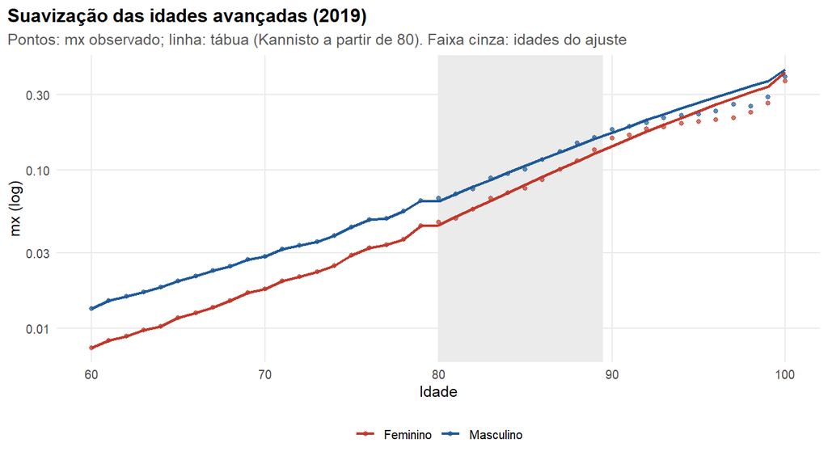

Figura 2: Taxas observadas e suavizadas nas idades avançadas (2019)

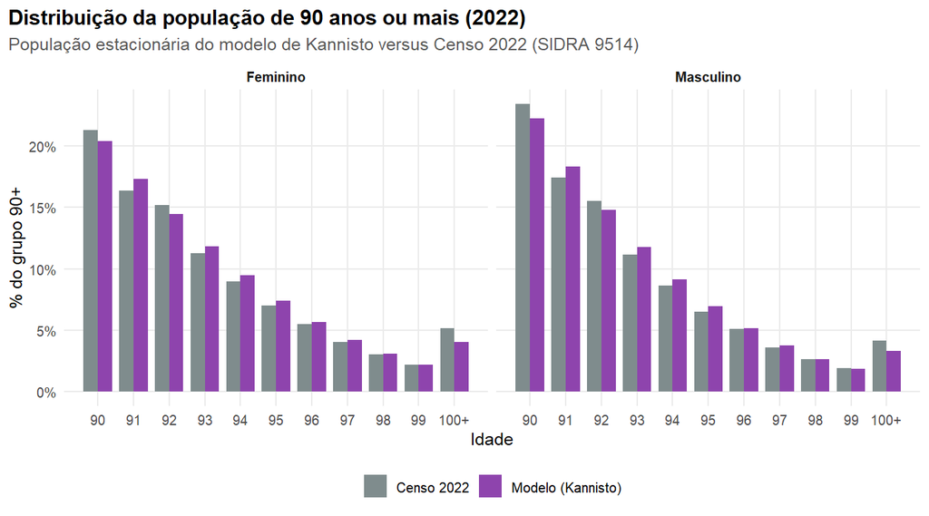

Figura 3: Divisão do grupo 90+ pelo modelo e pelo Censo 2022

## 3.3 Funções da tábua

- $q_x = \dfrac{m_x}{1 + (1 - a_x)\,m_x}$, com $q_{100+} = 1$;
- $a_0$ pelas fórmulas de **Coale-Demeny** (Preston, Heuveline e Guillot, 2001, Tabela 3.3): para homens, $a_0 = 0{,}045 + 2{,}684\,m_0$; para mulheres, $a_0 = 0{,}053 + 2{,}800\,m_0$ (quando $m_0 < 0{,}107$);
- $a_1$ supondo força de mortalidade exponencialmente decrescente entre 1 e 2 anos, $a_1 = 1/k - 1/(e^k - 1)$ com $k = \ln(m_1/m_2)$. Isso dá cerca de 0,44 em vez de 0,5, porque no segundo ano de vida os óbitos se concentram nos primeiros meses;
- $a_x = 0{,}5$ nas demais idades fechadas;
- $l_0 = 100.000$, $l_{x+1} = l_x(1 - q_x)$, $d_x = l_x q_x$, $L_x = l_{x+1} + a_x d_x$, $L_{100+} = l_{100}/m_{100+}$, $T_x = \sum_{y \ge x} L_y$ e $e_x = T_x / l_x$.

## 3.4 Lee-Carter

O modelo de Lee e Carter (1992) decompõe o log da força de mortalidade em

$$\log \mu_{x,t} = a_x + b_x\,k_t,$$

em que $a_x$ é o padrão etário médio, $k_t$ é um índice do nível geral de mortalidade e $b_x$ é a sensibilidade de cada idade a $k_t$. O ajuste usa `StMoMo::lc(link = "log")`, que supõe $D_{x,t} \sim \text{Poisson}(E_{x,t}\,\mu_{x,t})$ (Brouhns, Denuit e Vermunt, 2002), com $\sum_x b_x = 1$ e $\sum_t k_t = 0$, nas idades 0–100. Nas idades 80+, os óbitos usados são os ajustados pelo Kannisto ($\hat m_x E_x$), para manter a coerência com a tábua.

O índice $k_t$ é projetado por um **ARIMA(0,1,0) com drift** (passeio aleatório com tendência). Os intervalos de e0 e e65 vêm de 1.000 trajetórias simuladas de $k_t$, cada uma convertida em uma tábua completa.

**Cenários:**

- **pré-COVID**: ajuste em 2000–2019;
- **com COVID**: ajuste em 2000–2023, incluindo 2020–2021.

# 4 Resultados

## 4.1 Tábuas de mortalidade

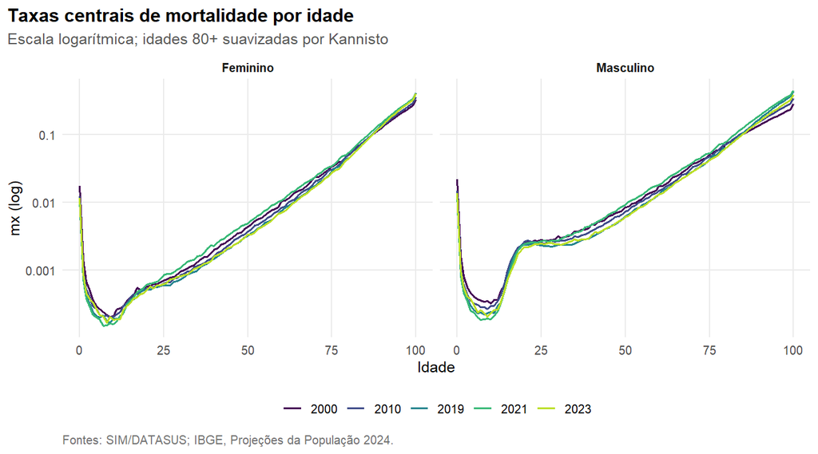

Figura 4: Taxas centrais de mortalidade por idade, anos selecionados

Tabela 3: Extrato da tábua de 2023 (idades selecionadas)

| Idade | qx (H) | qx (M) | lx (H) | lx (M) | ex (H) | ex (M) |
| --- | --- | --- | --- | --- | --- | --- |
| 0 | 0.01357 | 0.01146 | 100.000 | 100.000 | 73,18 | 79,84 |
| 1 | 0.00099 | 0.00090 | 98.643 | 98.854 | 73,19 | 79,77 |
| 5 | 0.00031 | 0.00026 | 98.412 | 98.649 | 69,36 | 75,93 |
| 20 | 0.00218 | 0.00051 | 97.475 | 98.233 | 54,92 | 61,22 |
| 40 | 0.00333 | 0.00161 | 92.628 | 96.561 | 37,25 | 42,07 |
| 60 | 0.01297 | 0.00712 | 81.248 | 90.134 | 20,78 | 24,20 |
| 65 | 0.01957 | 0.01106 | 75.301 | 86.369 | 17,21 | 20,13 |
| 80 | 0.06216 | 0.04344 | 44.285 | 61.714 | 8,47 | 9,68 |
| 90 | 0.14803 | 0.12934 | 16.119 | 28.044 | 4,65 | 4,93 |
| 100+ | 1.00000 | 1.00000 | 1.510 | 2.924 | 2,57 | 2,46 |

As tábuas completas de todos os anos estão em `data/processed/tabuas_mortalidade.parquet`.

## 4.2 Comparação com o IBGE

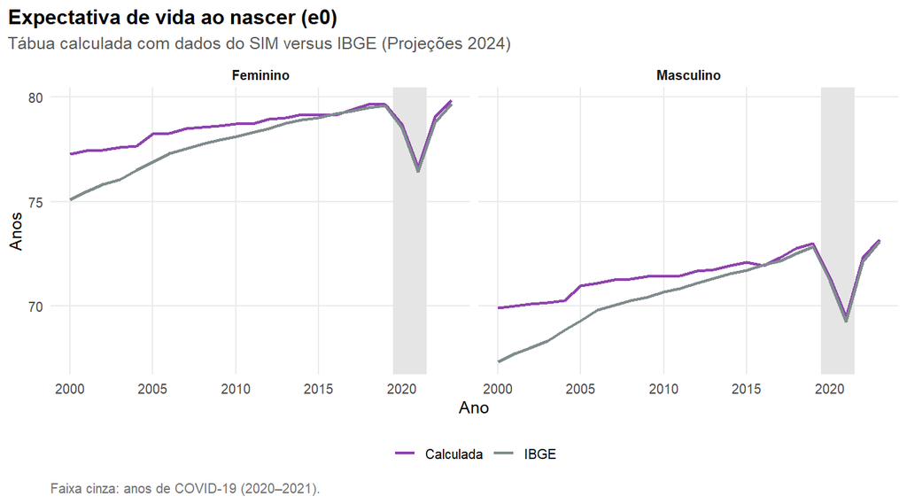

Figura 5: e0 calculada com dados do SIM e e0 oficial do IBGE

Tabela 4: e0 calculada e oficial (IBGE), em anos

| Ano | Calc. (H) | IBGE (H) | Dif. (H) | Calc. (M) | IBGE (M) | Dif. (M) |
| --- | --- | --- | --- | --- | --- | --- |
| 2000 | 69,88 | 67,32 | 2,56 | 77,28 | 75,08 | 2,20 |
| 2005 | 70,95 | 69,27 | 1,68 | 78,25 | 76,88 | 1,36 |
| 2010 | 71,42 | 70,67 | 0,74 | 78,73 | 78,12 | 0,61 |
| 2015 | 72,09 | 71,71 | 0,38 | 79,15 | 79,03 | 0,12 |
| 2019 | 72,99 | 72,84 | 0,15 | 79,66 | 79,60 | 0,06 |
| 2020 | 71,35 | 71,19 | 0,16 | 78,69 | 78,52 | 0,17 |
| 2021 | 69,44 | 69,25 | 0,18 | 76,62 | 76,42 | 0,20 |
| 2023 | 73,18 | 73,07 | 0,11 | 79,84 | 79,68 | 0,16 |

Em 2000, a e0 calculada supera a oficial em 2,6 anos para homens e 2,2 anos para mulheres. Em 2023, a diferença é de 0,1 e 0,2 anos. As diferenças têm três origens:

1. **Sub-registro de óbitos no SIM.** O IBGE corrige o número de óbitos com estimativas de cobertura, sobretudo nos estados do Norte e do Nordeste e nos primeiros anos da série. Sem essa correção, a mortalidade fica subestimada e a e0, superestimada. A queda da diferença ao longo do tempo acompanha a melhora da cobertura (Figura 1).
2. **Mortalidade infantil.** O sub-registro de óbitos infantis é historicamente maior e, como a e0 é muito sensível a $q_0$, deve responder por boa parte da diferença no início do período.
3. **Idades avançadas.** O IBGE usa métodos próprios para fechar a tábua; aqui usamos Kannisto a partir dos 80 anos.

Para uso atuarial, as tábuas deste projeto devem ser vistas como **tábuas de população geral não corrigidas**. Usá-las em precificação exigiria corrigir o sub-registro e ajustar ao perfil da carteira.

## 4.3 Lee-Carter: parâmetros

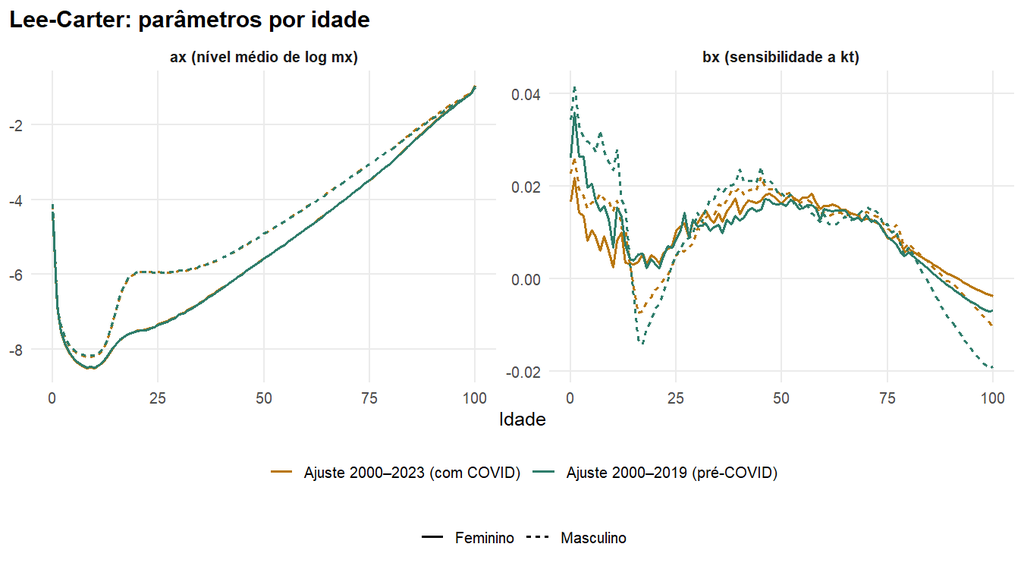

Figura 6: Parâmetros ax e bx por idade

O $a_x$ reproduz o formato clássico da curva de mortalidade: alto no primeiro ano, mínimo por volta dos 10 anos, a “corcova” de causas externas entre homens jovens e crescimento quase log-linear na idade adulta. O $b_x$ mostra **em que idades a mortalidade mais caiu**:

- valores altos na infância (queda da mortalidade infantil) e entre 30 e 70 anos;
- **valores negativos entre homens de 15 a 25 anos**: nessas idades a mortalidade *subiu* no período, efeito da violência (causas externas);
- $b_x$ negativo também nas idades 85+, onde a mortalidade medida pelo SIM aumentou. Isso é coerente com a melhora da cobertura do registro de óbitos de idosos, não necessariamente com uma piora real.

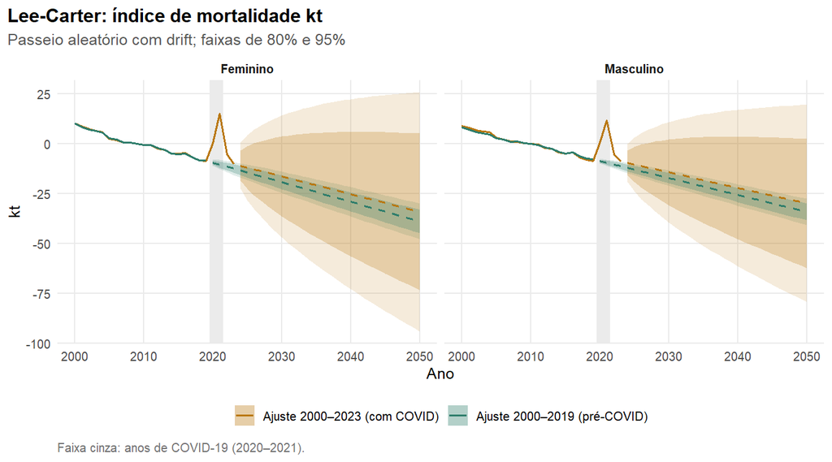

Figura 7: Índice kt ajustado e projetado

No cenário com COVID, o $k_t$ salta de cerca de −9 em 2019 para 15 em 2021 e volta ao nível pré-pandemia já em 2023. Como o drift de um passeio aleatório depende só do primeiro e do último ponto da série ($\hat\delta = (k_T - k_1)/(T - 1)$), o choque **quase não altera a tendência central**. O que muda é a **volatilidade estimada**: a variância dos incrementos de $k_t$ explode, e com ela a largura dos intervalos.

## 4.4 Projeção da expectativa de vida

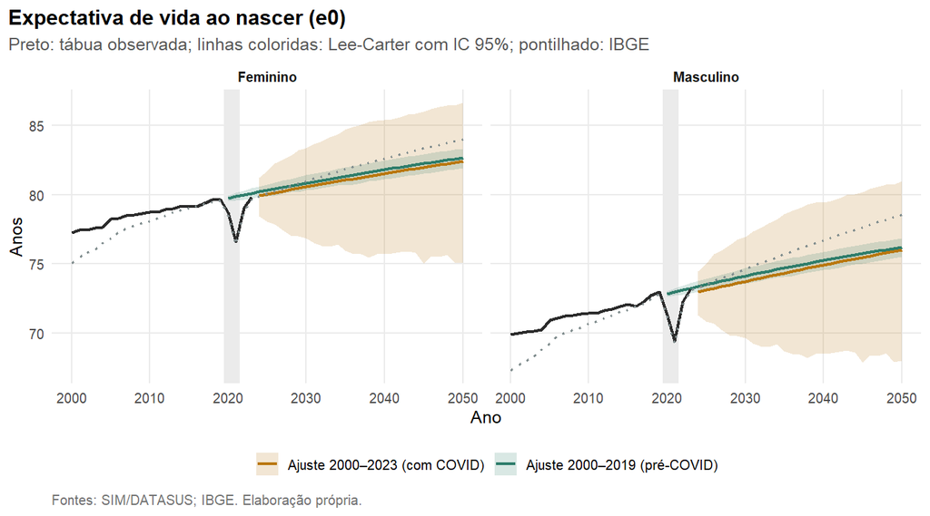

Figura 8: e0 observada e projetada até 2050

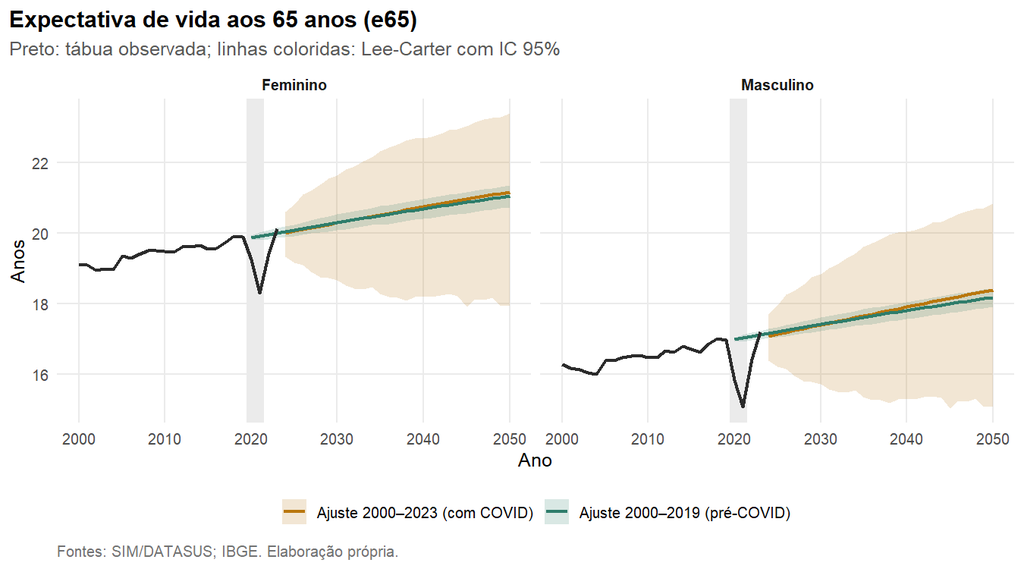

Figura 9: e65 observada e projetada até 2050

Tabela 5: Expectativa de vida projetada (central e IC 95%), em anos

| Indicador | Sexo | Ajuste | 2030 | 2040 | 2050 |
| --- | --- | --- | --- | --- | --- |
| e0 | Feminino | 2000–2019 | 80,9 (80,3–81,4) | 81,8 (81,1–82,5) | 82,7 (81,9–83,3) |
| e0 | Feminino | 2000–2023 | 80,6 (76,9–83,4) | 81,5 (75,7–85,4) | 82,4 (75,1–86,6) |
| e0 | Masculino | 2000–2019 | 74,1 (73,6–74,7) | 75,2 (74,6–75,9) | 76,2 (75,5–76,9) |
| e0 | Masculino | 2000–2023 | 73,7 (69,6–77,0) | 74,9 (68,5–79,5) | 76,0 (68,0–81,0) |
| e65 | Feminino | 2000–2019 | 20,3 (20,1–20,5) | 20,7 (20,4–21,0) | 21,0 (20,7–21,3) |
| e65 | Feminino | 2000–2023 | 20,3 (18,7–21,6) | 20,7 (18,2–22,7) | 21,2 (17,9–23,4) |
| e65 | Masculino | 2000–2019 | 17,4 (17,2–17,6) | 17,8 (17,6–18,0) | 18,2 (17,9–18,4) |
| e65 | Masculino | 2000–2023 | 17,4 (15,7–18,8) | 17,9 (15,3–20,0) | 18,4 (15,1–20,8) |

Em 2050, o cenário pré-COVID projeta e0 de 82,7 anos para mulheres (IC 95%: 81,9–83,3) e 76,2 para homens. Com a COVID no ajuste, as estimativas centrais quase não mudam (82,4 e 76,0), mas o IC 95% para mulheres passa a ir de 75,1 a 86,6 anos.

Duas conclusões para a prática atuarial:

1. **A COVID afeta mais a incerteza que a tendência.** Incluir 2020–2021 sem tratamento faz o modelo tratar choques dessa magnitude como recorrentes, e os intervalos ficam largos demais para serem úteis. As alternativas usuais são excluir esses anos, dar-lhes peso menor ou modelá-los como *outliers* (intervenção no ARIMA de $k_t$).
2. **As projeções ficam abaixo das do IBGE** (em 2050, e0 de 84,0 anos para mulheres e 78,6 para homens). O motivo é o mesmo sub-registro visto acima: a cobertura do SIM passou de cerca de 85% para 98% entre 2000 e 2019, então parte da queda real da mortalidade ficou escondida pelo aumento dos óbitos registrados. O drift de $k_t$ sai **subestimado**, e com ele o ganho de longevidade projetado, um viés que, em previdência, leva a subestimar passivos.

# 5 Diagnóstico

## 5.1 Resíduos

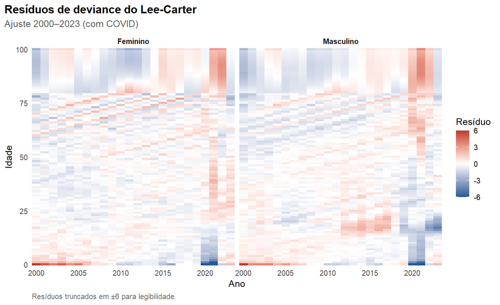

Figura 10: Resíduos de deviance — ajuste 2000–2023

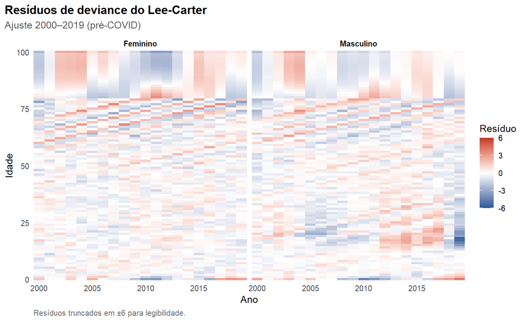

Figura 11: Resíduos de deviance — ajuste 2000–2019

- **2020–2021** aparecem como colunas fortemente positivas nas idades adultas e idosas e negativas na infância: a COVID elevou a mortalidade sobretudo dos mais velhos, um padrão etário diferente do $b_x$ histórico, que é alto na infância. Um único fator não descreve os dois movimentos. No ajuste pré-COVID essas colunas desaparecem;
- uma **faixa positiva entre homens de 12 a 25 anos na década de 2010** reflete a dinâmica própria da mortalidade por violência, que não segue o índice geral $k_t$;
- nas **idades 80+**, os resíduos refletem a variação ano a ano dos parâmetros do Kannisto, que não segue exatamente a estrutura $a_x + b_x k_t$;
- resíduos positivos na **idade 0 no início da série** combinam com a queda mais rápida da mortalidade infantil nesse período.

Modelos com mais fatores ou com efeito de coorte (Renshaw-Haberman, por exemplo) poderiam capturar parte dessas estruturas.

## 5.2 Backtesting

O modelo foi ajustado em 2000–2014 e projetado para 2015–2019; as projeções foram comparadas com as tábuas observadas.

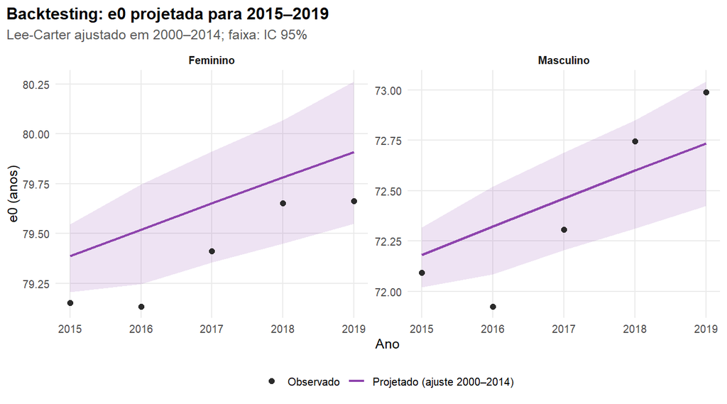

Figura 12: Backtesting: e0 projetada × observada (2015–2019)

Tabela 6: Erros do backtesting

| Sexo | Ano | e0 proj. | e0 obs. | Erro (anos) | Dentro do IC 95% | RMSE log mx |
| --- | --- | --- | --- | --- | --- | --- |
| Masculino | 2015 | 72,18 | 72,09 | 0,09 | sim | 0,048 |
| Masculino | 2016 | 72,32 | 71,93 | 0,40 | não | 0,048 |
| Masculino | 2017 | 72,46 | 72,31 | 0,16 | sim | 0,049 |
| Masculino | 2018 | 72,60 | 72,75 | -0,14 | sim | 0,066 |
| Masculino | 2019 | 72,74 | 72,99 | -0,25 | sim | 0,097 |
| Feminino | 2015 | 79,39 | 79,15 | 0,24 | não | 0,053 |
| Feminino | 2016 | 79,52 | 79,13 | 0,39 | não | 0,054 |
| Feminino | 2017 | 79,65 | 79,41 | 0,24 | sim | 0,050 |
| Feminino | 2018 | 79,78 | 79,65 | 0,13 | sim | 0,057 |
| Feminino | 2019 | 79,91 | 79,66 | 0,25 | sim | 0,057 |

O erro absoluto médio da e0 foi de 0,23 ano, e 7 de 10 observações ficaram dentro do IC 95%.

# 6 Limitações

- **Sub-registro**: os óbitos do SIM não foram corrigidos pela cobertura. As tábuas tendem a superestimar a longevidade, sobretudo no início do período.
- **Exposição**: usa-se a população em 1º de julho como aproximação da exposição ao risco, e a população vem de projeções (não de contagens), revisadas após o Censo 2022.
- **Idades 90+**: a divisão do grupo aberto depende do modelo de Kannisto e da hipótese de população estacionária, que ignora o crescimento das coortes.
- **Lee-Carter**: um único fator ($b_x$ fixo) não capta mudanças no padrão etário da melhora nem efeitos de coorte. Os intervalos consideram só a incerteza de $k_t$, não a dos parâmetros $a_x$ e $b_x$, e por isso são estreitos.
- **COVID**: nenhum dos cenários modela explicitamente o choque; os dois limites (excluir ou incluir sem tratamento) servem como referência.

# 7 Referências